# Evaluación Interactiva de Matemáticas ICFES

Un experimento consiste en medir el alcance horizontal de un proyectil en funcion del angulo con el que se lanza (respecto a la horizontal). En la grafica se registran los resultados de 106 lanzamientos realizados con la misma velocidad inicial.

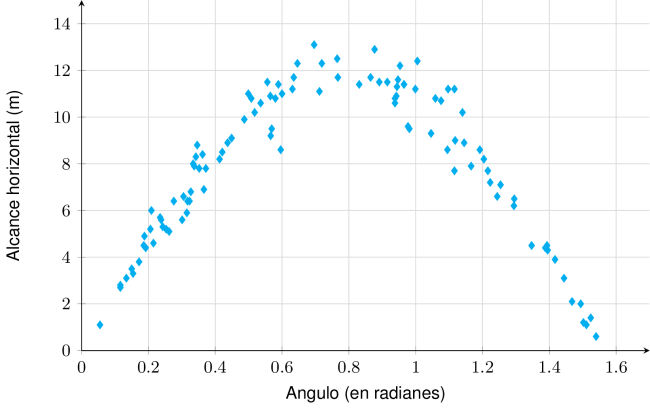

El comportamiento del alcance respecto al angulo es

Para analizar el comportamiento del alcance respecto al angulo, debemos observar dos aspectos clave en la grafica de dispersion:

**1. Tipo de relacion (lineal vs no lineal):**

La relacion entre el angulo y el alcance sigue la ecuacion del movimiento de proyectiles:

$$R = \frac{v_0^2
\sin(2\theta)}{g}$$

Esta es una funcion senoidal, por lo tanto **no lineal**. En la grafica se observa claramente una forma parabolica con un maximo aproximadamente en $\theta \approx 0.78$ radianes ($\approx 45°$).

**2. Patron de dispersion:**

Observando la grafica:

- En los extremos (angulos cercanos a 0 y 1.5 radianes): los puntos estan mas concentrados
- En la zona central (alcances mayores, alrededor de 10-13 m): los puntos muestran mayor variabilidad

Esto indica que **la dispersion es proporcional al alcance**, no al angulo. Fisicamente, esto tiene sentido porque los errores experimentales se amplifican en trayectorias mas largas.

**Conclusion:**

El comportamiento es **no lineal** (forma parabolica) y **mas disperso cuanto mayor sea el alcance** (mayor variabilidad en valores altos de alcance).

- **Verdadero**. La relacion es no lineal (forma parabolica) y la dispersion aumenta proporcionalmente al alcance.
- **Falso**. Aunque la dispersion si aumenta con el alcance, la relacion NO es lineal.
- **Falso**. Si bien la relacion es no lineal, la dispersion NO aumenta con el angulo sino con el alcance.
- **Falso**. La relacion no es lineal (es parabolica/senoidal) y la dispersion no depende del angulo sino del alcance.

Un experimento consiste en medir el alcance horizontal de un proyectil en funcion del angulo con el que se lanza (respecto a la horizontal). En la grafica se registran los resultados de 97 lanzamientos realizados con la misma velocidad inicial.

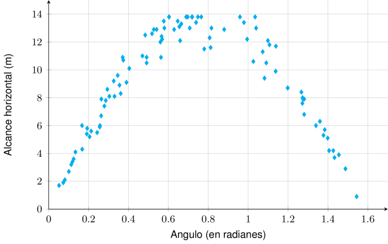

El comportamiento del alcance respecto al angulo es

Para analizar el comportamiento del alcance respecto al angulo, debemos observar dos aspectos clave en la grafica de dispersion:

**1. Tipo de relacion (lineal vs no lineal):**

La relacion entre el angulo y el alcance sigue la ecuacion del movimiento de proyectiles:

$$R = \frac{v_0^2
\sin(2\theta)}{g}$$

Esta es una funcion senoidal, por lo tanto **no lineal**. En la grafica se observa claramente una forma parabolica con un maximo aproximadamente en $\theta \approx 0.78$ radianes ($\approx 45°$).

**2. Patron de dispersion:**

Observando la grafica:

- En los extremos (angulos cercanos a 0 y 1.5 radianes): los puntos estan mas concentrados
- En la zona central (alcances mayores, alrededor de 10-13 m): los puntos muestran mayor variabilidad

Esto indica que **la dispersion es proporcional al alcance**, no al angulo. Fisicamente, esto tiene sentido porque los errores experimentales se amplifican en trayectorias mas largas.

**Conclusion:**

El comportamiento es **no lineal** (forma parabolica) y **mas disperso cuanto mayor sea el alcance** (mayor variabilidad en valores altos de alcance).

- **Falso**. Si bien la relacion es no lineal, la dispersion NO aumenta con el angulo sino con el alcance.
- **Verdadero**. La relacion es no lineal (forma parabolica) y la dispersion aumenta proporcionalmente al alcance.
- **Falso**. Aunque la dispersion si aumenta con el alcance, la relacion NO es lineal.
- **Falso**. La relacion no es lineal (es parabolica/senoidal) y la dispersion no depende del angulo sino del alcance.

Un experimento consiste en medir el alcance horizontal de un proyectil en funcion del angulo con el que se lanza (respecto a la horizontal). En la grafica se registran los resultados de 100 lanzamientos realizados con la misma velocidad inicial.

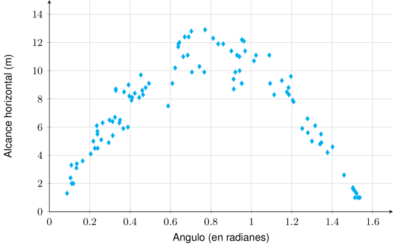

El comportamiento del alcance respecto al angulo es

Para analizar el comportamiento del alcance respecto al angulo, debemos observar dos aspectos clave en la grafica de dispersion:

**1. Tipo de relacion (lineal vs no lineal):**

La relacion entre el angulo y el alcance sigue la ecuacion del movimiento de proyectiles:

$$R = \frac{v_0^2
\sin(2\theta)}{g}$$

Esta es una funcion senoidal, por lo tanto **no lineal**. En la grafica se observa claramente una forma parabolica con un maximo aproximadamente en $\theta \approx 0.78$ radianes ($\approx 45°$).

**2. Patron de dispersion:**

Observando la grafica:

- En los extremos (angulos cercanos a 0 y 1.5 radianes): los puntos estan mas concentrados
- En la zona central (alcances mayores, alrededor de 10-13 m): los puntos muestran mayor variabilidad

Esto indica que **la dispersion es proporcional al alcance**, no al angulo. Fisicamente, esto tiene sentido porque los errores experimentales se amplifican en trayectorias mas largas.

**Conclusion:**

El comportamiento es **no lineal** (forma parabolica) y **mas disperso cuanto mayor sea el alcance** (mayor variabilidad en valores altos de alcance).

- **Falso**. Si bien la relacion es no lineal, la dispersion NO aumenta con el angulo sino con el alcance.
- **Verdadero**. La relacion es no lineal (forma parabolica) y la dispersion aumenta proporcionalmente al alcance.
- **Falso**. Aunque la dispersion si aumenta con el alcance, la relacion NO es lineal.
- **Falso**. La relacion no es lineal (es parabolica/senoidal) y la dispersion no depende del angulo sino del alcance.

Un experimento consiste en medir el alcance horizontal de un proyectil en funcion del angulo con el que se lanza (respecto a la horizontal). En la grafica se registran los resultados de 95 lanzamientos realizados con la misma velocidad inicial.

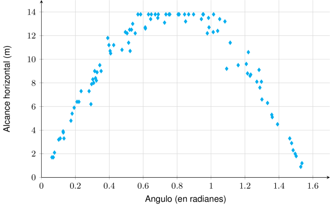

El comportamiento del alcance respecto al angulo es

Para analizar el comportamiento del alcance respecto al angulo, debemos observar dos aspectos clave en la grafica de dispersion:

**1. Tipo de relacion (lineal vs no lineal):**

La relacion entre el angulo y el alcance sigue la ecuacion del movimiento de proyectiles:

$$R = \frac{v_0^2
\sin(2\theta)}{g}$$

Esta es una funcion senoidal, por lo tanto **no lineal**. En la grafica se observa claramente una forma parabolica con un maximo aproximadamente en $\theta \approx 0.78$ radianes ($\approx 45°$).

**2. Patron de dispersion:**

Observando la grafica:

- En los extremos (angulos cercanos a 0 y 1.5 radianes): los puntos estan mas concentrados
- En la zona central (alcances mayores, alrededor de 10-13 m): los puntos muestran mayor variabilidad

Esto indica que **la dispersion es proporcional al alcance**, no al angulo. Fisicamente, esto tiene sentido porque los errores experimentales se amplifican en trayectorias mas largas.

**Conclusion:**

El comportamiento es **no lineal** (forma parabolica) y **mas disperso cuanto mayor sea el alcance** (mayor variabilidad en valores altos de alcance).

- **Verdadero**. La relacion es no lineal (forma parabolica) y la dispersion aumenta proporcionalmente al alcance.
- **Falso**. Si bien la relacion es no lineal, la dispersion NO aumenta con el angulo sino con el alcance.
- **Falso**. Aunque la dispersion si aumenta con el alcance, la relacion NO es lineal.
- **Falso**. La relacion no es lineal (es parabolica/senoidal) y la dispersion no depende del angulo sino del alcance.

Un experimento consiste en medir el alcance horizontal de un proyectil en funcion del angulo con el que se lanza (respecto a la horizontal). En la grafica se registran los resultados de 110 lanzamientos realizados con la misma velocidad inicial.

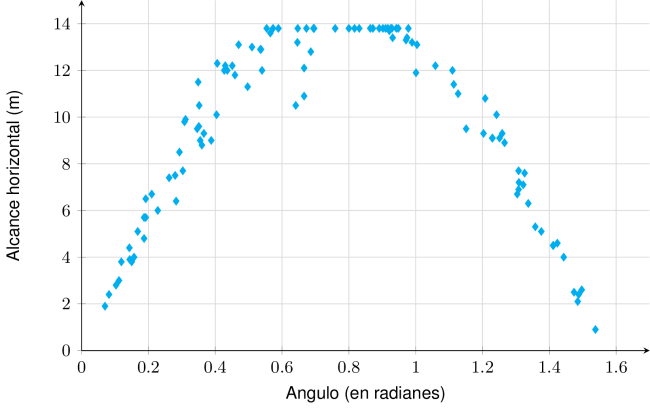

El comportamiento del alcance respecto al angulo es

Para analizar el comportamiento del alcance respecto al angulo, debemos observar dos aspectos clave en la grafica de dispersion:

**1. Tipo de relacion (lineal vs no lineal):**

La relacion entre el angulo y el alcance sigue la ecuacion del movimiento de proyectiles:

$$R = \frac{v_0^2
\sin(2\theta)}{g}$$

Esta es una funcion senoidal, por lo tanto **no lineal**. En la grafica se observa claramente una forma parabolica con un maximo aproximadamente en $\theta \approx 0.78$ radianes ($\approx 45°$).

**2. Patron de dispersion:**

Observando la grafica:

- En los extremos (angulos cercanos a 0 y 1.5 radianes): los puntos estan mas concentrados
- En la zona central (alcances mayores, alrededor de 10-13 m): los puntos muestran mayor variabilidad

Esto indica que **la dispersion es proporcional al alcance**, no al angulo. Fisicamente, esto tiene sentido porque los errores experimentales se amplifican en trayectorias mas largas.

**Conclusion:**

El comportamiento es **no lineal** (forma parabolica) y **mas disperso cuanto mayor sea el alcance** (mayor variabilidad en valores altos de alcance).

- **Falso**. Si bien la relacion es no lineal, la dispersion NO aumenta con el angulo sino con el alcance.
- **Falso**. Aunque la dispersion si aumenta con el alcance, la relacion NO es lineal.
- **Falso**. La relacion no es lineal (es parabolica/senoidal) y la dispersion no depende del angulo sino del alcance.
- **Verdadero**. La relacion es no lineal (forma parabolica) y la dispersion aumenta proporcionalmente al alcance.

Un experimento consiste en medir el alcance horizontal de un proyectil en funcion del angulo con el que se lanza (respecto a la horizontal). En la grafica se registran los resultados de 90 lanzamientos realizados con la misma velocidad inicial.

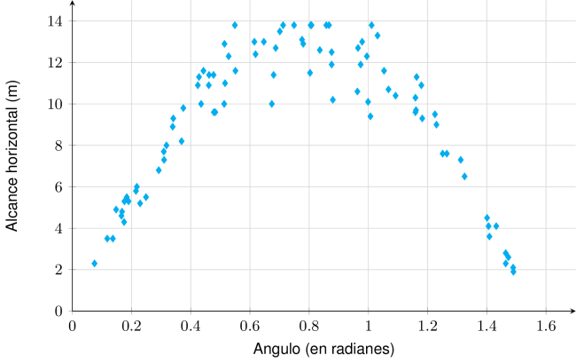

El comportamiento del alcance respecto al angulo es

Para analizar el comportamiento del alcance respecto al angulo, debemos observar dos aspectos clave en la grafica de dispersion:

**1. Tipo de relacion (lineal vs no lineal):**

La relacion entre el angulo y el alcance sigue la ecuacion del movimiento de proyectiles:

$$R = \frac{v_0^2
\sin(2\theta)}{g}$$

Esta es una funcion senoidal, por lo tanto **no lineal**. En la grafica se observa claramente una forma parabolica con un maximo aproximadamente en $\theta \approx 0.78$ radianes ($\approx 45°$).

**2. Patron de dispersion:**

Observando la grafica:

- En los extremos (angulos cercanos a 0 y 1.5 radianes): los puntos estan mas concentrados
- En la zona central (alcances mayores, alrededor de 10-13 m): los puntos muestran mayor variabilidad

Esto indica que **la dispersion es proporcional al alcance**, no al angulo. Fisicamente, esto tiene sentido porque los errores experimentales se amplifican en trayectorias mas largas.

**Conclusion:**

El comportamiento es **no lineal** (forma parabolica) y **mas disperso cuanto mayor sea el alcance** (mayor variabilidad en valores altos de alcance).

- **Falso**. Si bien la relacion es no lineal, la dispersion NO aumenta con el angulo sino con el alcance.
- **Falso**. Aunque la dispersion si aumenta con el alcance, la relacion NO es lineal.
- **Falso**. La relacion no es lineal (es parabolica/senoidal) y la dispersion no depende del angulo sino del alcance.
- **Verdadero**. La relacion es no lineal (forma parabolica) y la dispersion aumenta proporcionalmente al alcance.

Un experimento consiste en medir el alcance horizontal de un proyectil en funcion del angulo con el que se lanza (respecto a la horizontal). En la grafica se registran los resultados de 110 lanzamientos realizados con la misma velocidad inicial.

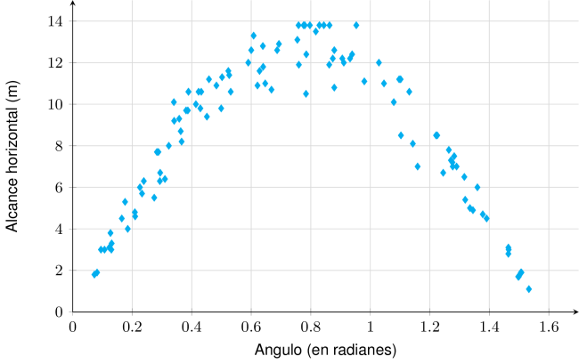

El comportamiento del alcance respecto al angulo es

Para analizar el comportamiento del alcance respecto al angulo, debemos observar dos aspectos clave en la grafica de dispersion:

**1. Tipo de relacion (lineal vs no lineal):**

La relacion entre el angulo y el alcance sigue la ecuacion del movimiento de proyectiles:

$$R = \frac{v_0^2
\sin(2\theta)}{g}$$

Esta es una funcion senoidal, por lo tanto **no lineal**. En la grafica se observa claramente una forma parabolica con un maximo aproximadamente en $\theta \approx 0.78$ radianes ($\approx 45°$).

**2. Patron de dispersion:**

Observando la grafica:

- En los extremos (angulos cercanos a 0 y 1.5 radianes): los puntos estan mas concentrados
- En la zona central (alcances mayores, alrededor de 10-13 m): los puntos muestran mayor variabilidad

Esto indica que **la dispersion es proporcional al alcance**, no al angulo. Fisicamente, esto tiene sentido porque los errores experimentales se amplifican en trayectorias mas largas.

**Conclusion:**

El comportamiento es **no lineal** (forma parabolica) y **mas disperso cuanto mayor sea el alcance** (mayor variabilidad en valores altos de alcance).

- **Falso**. Aunque la dispersion si aumenta con el alcance, la relacion NO es lineal.
- **Falso**. La relacion no es lineal (es parabolica/senoidal) y la dispersion no depende del angulo sino del alcance.
- **Falso**. Si bien la relacion es no lineal, la dispersion NO aumenta con el angulo sino con el alcance.
- **Verdadero**. La relacion es no lineal (forma parabolica) y la dispersion aumenta proporcionalmente al alcance.

Un experimento consiste en medir el alcance horizontal de un proyectil en funcion del angulo con el que se lanza (respecto a la horizontal). En la grafica se registran los resultados de 100 lanzamientos realizados con la misma velocidad inicial.

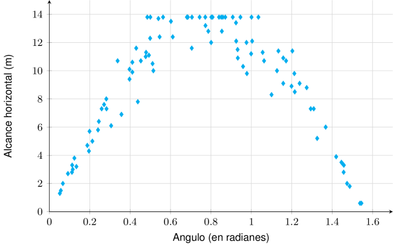

El comportamiento del alcance respecto al angulo es

Para analizar el comportamiento del alcance respecto al angulo, debemos observar dos aspectos clave en la grafica de dispersion:

**1. Tipo de relacion (lineal vs no lineal):**

La relacion entre el angulo y el alcance sigue la ecuacion del movimiento de proyectiles:

$$R = \frac{v_0^2
\sin(2\theta)}{g}$$

Esta es una funcion senoidal, por lo tanto **no lineal**. En la grafica se observa claramente una forma parabolica con un maximo aproximadamente en $\theta \approx 0.78$ radianes ($\approx 45°$).

**2. Patron de dispersion:**

Observando la grafica:

- En los extremos (angulos cercanos a 0 y 1.5 radianes): los puntos estan mas concentrados
- En la zona central (alcances mayores, alrededor de 10-13 m): los puntos muestran mayor variabilidad

Esto indica que **la dispersion es proporcional al alcance**, no al angulo. Fisicamente, esto tiene sentido porque los errores experimentales se amplifican en trayectorias mas largas.

**Conclusion:**

El comportamiento es **no lineal** (forma parabolica) y **mas disperso cuanto mayor sea el alcance** (mayor variabilidad en valores altos de alcance).

- **Verdadero**. La relacion es no lineal (forma parabolica) y la dispersion aumenta proporcionalmente al alcance.
- **Falso**. Si bien la relacion es no lineal, la dispersion NO aumenta con el angulo sino con el alcance.
- **Falso**. Aunque la dispersion si aumenta con el alcance, la relacion NO es lineal.
- **Falso**. La relacion no es lineal (es parabolica/senoidal) y la dispersion no depende del angulo sino del alcance.

Un experimento consiste en medir el alcance horizontal de un proyectil en funcion del angulo con el que se lanza (respecto a la horizontal). En la grafica se registran los resultados de 91 lanzamientos realizados con la misma velocidad inicial.

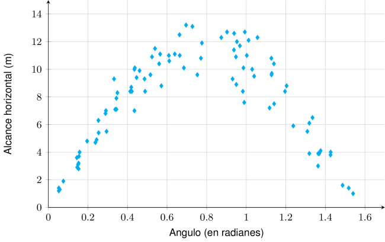

El comportamiento del alcance respecto al angulo es

Para analizar el comportamiento del alcance respecto al angulo, debemos observar dos aspectos clave en la grafica de dispersion:

**1. Tipo de relacion (lineal vs no lineal):**

La relacion entre el angulo y el alcance sigue la ecuacion del movimiento de proyectiles:

$$R = \frac{v_0^2
\sin(2\theta)}{g}$$

Esta es una funcion senoidal, por lo tanto **no lineal**. En la grafica se observa claramente una forma parabolica con un maximo aproximadamente en $\theta \approx 0.78$ radianes ($\approx 45°$).

**2. Patron de dispersion:**

Observando la grafica:

- En los extremos (angulos cercanos a 0 y 1.5 radianes): los puntos estan mas concentrados
- En la zona central (alcances mayores, alrededor de 10-13 m): los puntos muestran mayor variabilidad

Esto indica que **la dispersion es proporcional al alcance**, no al angulo. Fisicamente, esto tiene sentido porque los errores experimentales se amplifican en trayectorias mas largas.

**Conclusion:**

El comportamiento es **no lineal** (forma parabolica) y **mas disperso cuanto mayor sea el alcance** (mayor variabilidad en valores altos de alcance).

- **Falso**. Aunque la dispersion si aumenta con el alcance, la relacion NO es lineal.
- **Verdadero**. La relacion es no lineal (forma parabolica) y la dispersion aumenta proporcionalmente al alcance.
- **Falso**. Si bien la relacion es no lineal, la dispersion NO aumenta con el angulo sino con el alcance.
- **Falso**. La relacion no es lineal (es parabolica/senoidal) y la dispersion no depende del angulo sino del alcance.

Un experimento consiste en medir el alcance horizontal de un proyectil en funcion del angulo con el que se lanza (respecto a la horizontal). En la grafica se registran los resultados de 93 lanzamientos realizados con la misma velocidad inicial.

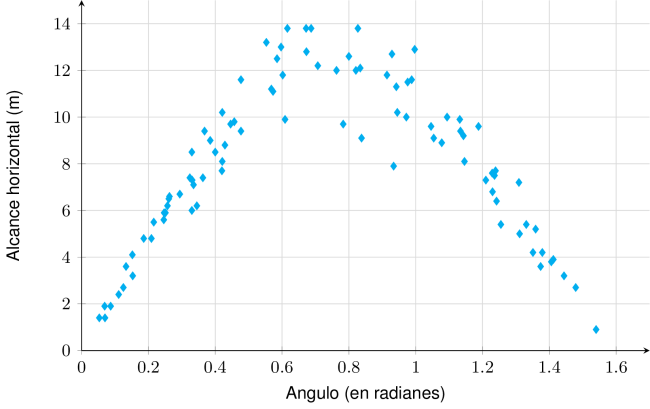

El comportamiento del alcance respecto al angulo es

Para analizar el comportamiento del alcance respecto al angulo, debemos observar dos aspectos clave en la grafica de dispersion:

**1. Tipo de relacion (lineal vs no lineal):**

La relacion entre el angulo y el alcance sigue la ecuacion del movimiento de proyectiles:

$$R = \frac{v_0^2
\sin(2\theta)}{g}$$

Esta es una funcion senoidal, por lo tanto **no lineal**. En la grafica se observa claramente una forma parabolica con un maximo aproximadamente en $\theta \approx 0.78$ radianes ($\approx 45°$).

**2. Patron de dispersion:**

Observando la grafica:

- En los extremos (angulos cercanos a 0 y 1.5 radianes): los puntos estan mas concentrados
- En la zona central (alcances mayores, alrededor de 10-13 m): los puntos muestran mayor variabilidad

Esto indica que **la dispersion es proporcional al alcance**, no al angulo. Fisicamente, esto tiene sentido porque los errores experimentales se amplifican en trayectorias mas largas.

**Conclusion:**

El comportamiento es **no lineal** (forma parabolica) y **mas disperso cuanto mayor sea el alcance** (mayor variabilidad en valores altos de alcance).

- **Falso**. Aunque la dispersion si aumenta con el alcance, la relacion NO es lineal.
- **Verdadero**. La relacion es no lineal (forma parabolica) y la dispersion aumenta proporcionalmente al alcance.
- **Falso**. Si bien la relacion es no lineal, la dispersion NO aumenta con el angulo sino con el alcance.
- **Falso**. La relacion no es lineal (es parabolica/senoidal) y la dispersion no depende del angulo sino del alcance.